# Exploratory Data Analysis on Quality of Red Wine

If we look at relationship between chemical properties. pH is highly correlated to fixed acidity and fixed acidity and desity are correlated.

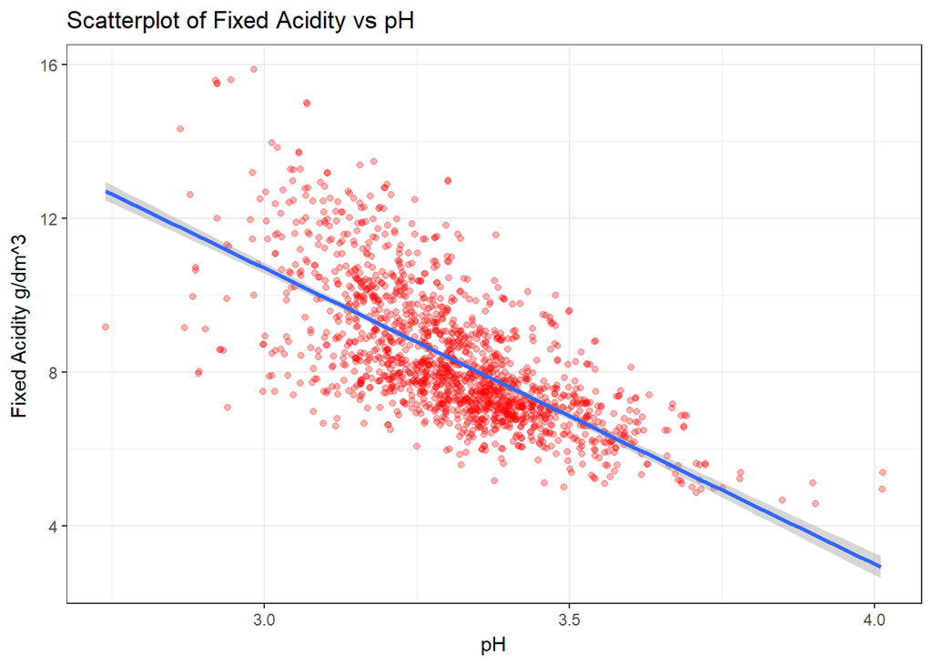

**PH is negatively related to acidity** which is a well know fact that the pH value decreases with increase in acidity

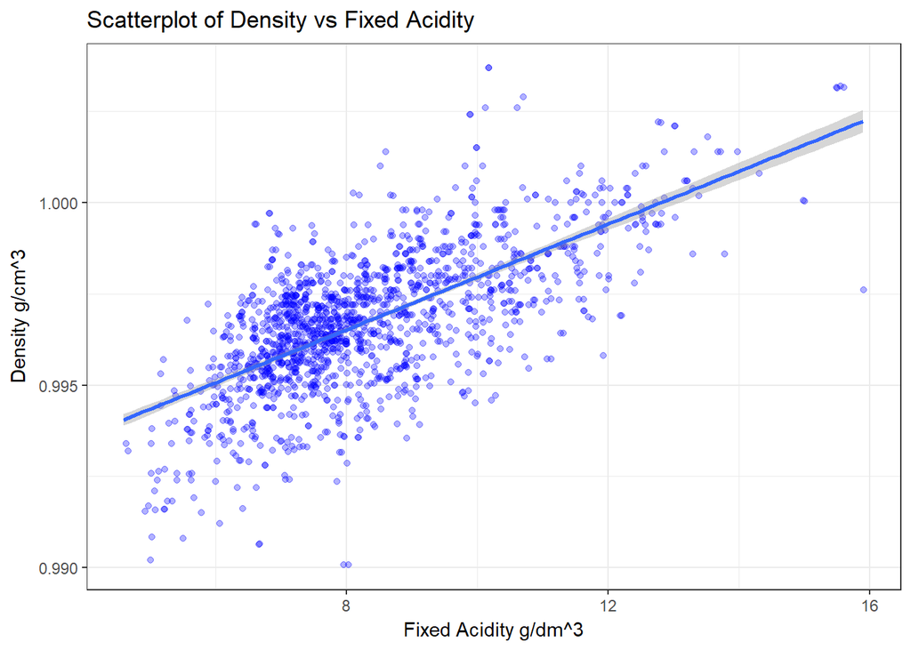

Density is positevly correlated to fixed acidity with a correlation coefficient of 0.66.

```
##
##  Pearson's product-moment correlation
##
## data:  redWine$alcohol and redWine$quality
## t = 21.639, df = 1597, p-value < 2.2e-16
## alternative hypothesis: true correlation is not equal to 0
## 95 percent confidence interval:
##  0.4373540 0.5132081
## sample estimates:
##       cor
## 0.4761663
```

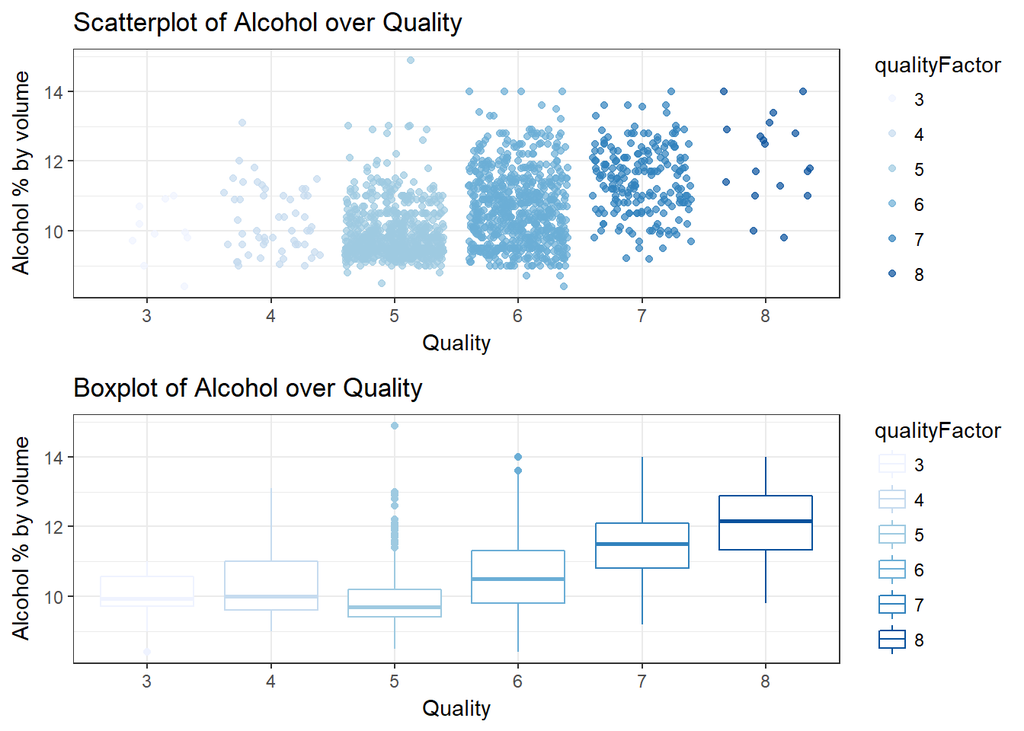

Looking at the above scatter plot we can see a positive realtionship between **quality and alcohol** This is more evident from the boxplot when we can see an increasing trend for mean of alcohol over quality.

```
##
##  Pearson's product-moment correlation
##
## data:  redWine$volatile.acidity and redWine$quality
## t = -16.954, df = 1597, p-value < 2.2e-16
## alternative hypothesis: true correlation is not equal to 0
## 95 percent confidence interval:
##  -0.4313210 -0.3482032
## sample estimates:
##        cor
## -0.3905578
```

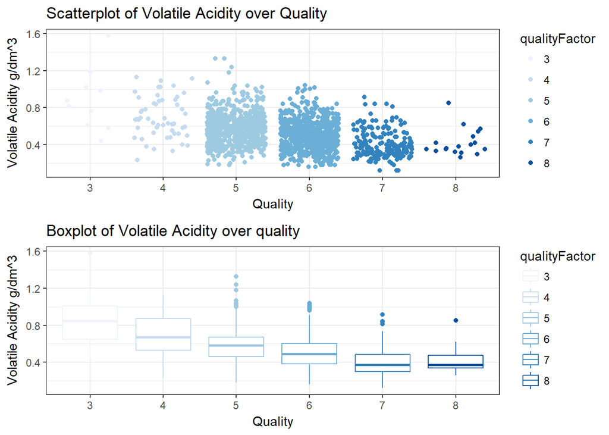

Here we see a inverse linear relationship between quality and Volatile Acidity. the trend is very sutle. similarly, it is more evident in the boxplot of volatile acidity over quality.

As the amount of volatile Acidity (acetic acid) in wine increase it leads to unpleasant, vulger taste of wine. which is evident with this inverse relationship with quaity of wine.

```
##
##  Pearson's product-moment correlation
##
## data:  redWine$sulphates and redWine$quality
## t = 10.38, df = 1597, p-value < 2.2e-16
## alternative hypothesis: true correlation is not equal to 0
## 95 percent confidence interval:
##  0.2049011 0.2967610
## sample estimates:
##       cor
## 0.2513971
```

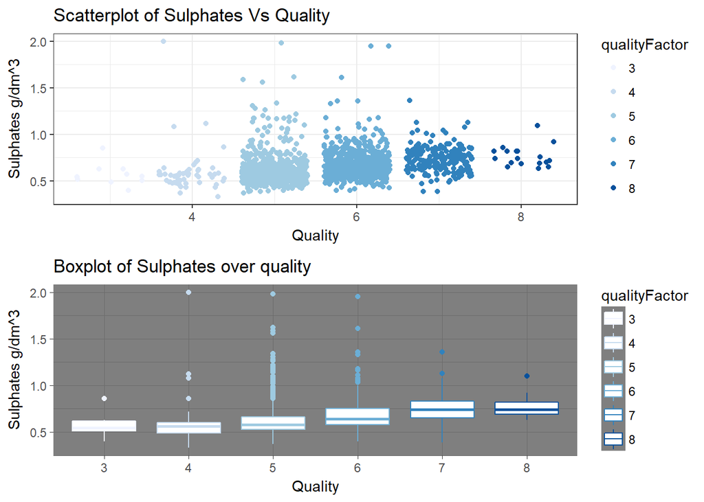

there is a slight linear relationship between quality and sulphates but as we look at box plot we can see as the the quality is increasing there are few outliers in the data which might be pulling the mean towards a higher value.

Correlation test reveals that there is slight to no relationship between quality and sulphates. As we consider correlation coefficient > 0.3 to have any kind of relationship.

# Multivariate plots section

```
##
## Calls:
## m1: lm(formula = quality ~ alcohol, data = redWine)
## m2: lm(formula = quality ~ alcohol + log10(sulphates), data = redWine)
## m3: lm(formula = quality ~ alcohol + log10(sulphates) + volatile.acidity,
##     data = redWine)
## m4: lm(formula = quality ~ alcohol + log10(sulphates) + volatile.acidity +
##     log10(residual.sugar), data = redWine)
## m5: lm(formula = quality ~ alcohol + log10(sulphates) + volatile.acidity +
##     log10(residual.sugar) + log10(chlorides), data = redWine)
## m6: lm(formula = quality ~ alcohol + log10(sulphates) + volatile.acidity +
##     log10(residual.sugar) + log10(chlorides) + log10(free.sulfur.dioxide1),
##     data = redWine)
## m7: lm(formula = quality ~ alcohol + log10(sulphates) + volatile.acidity +
##     log10(residual.sugar) + log10(chlorides) + log10(free.sulfur.dioxide1) +
##     log10(total.sulfur.dioxide1), data = redWine)
## m8: lm(formula = quality ~ alcohol + log10(sulphates) + volatile.acidity +
##     log10(residual.sugar) + log10(chlorides) + log10(free.sulfur.dioxide1) +
##     log10(total.sulfur.dioxide1) + density, data = redWine)
## m9: lm(formula = quality ~ alcohol + log10(sulphates) + volatile.acidity +
##     log10(residual.sugar) + log10(chlorides) + log10(free.sulfur.dioxide1) +
##     log10(total.sulfur.dioxide1) + density + pH, data = redWine)
## m10: lm(formula = quality ~ alcohol + log10(sulphates) + volatile.acidity +
##     log10(residual.sugar) + log10(chlorides) + log10(free.sulfur.dioxide1) +
##     log10(total.sulfur.dioxide1) + density + pH, data = redWine)
## m11: lm(formula = quality ~ alcohol + log10(sulphates) + volatile.acidity +
##     log10(residual.sugar) + log10(chlorides) + log10(free.sulfur.dioxide1) +
##     log10(total.sulfur.dioxide1) + density + pH + citric.acid,
##     data = redWine)
##
## ==========================================================================================================================================================================================
##                                      m1            m2            m3            m4            m5            m6            m7            m8            m9           m10           m11
## ------------------------------------------------------------------------------------------------------------------------------------------------------------------------------------------
##   (Intercept)                       1.875***      2.541***      3.369***      3.377***      3.062***      3.314***      3.923***     -1.636         8.747         8.747        -1.210
##                                    (0.175)       (0.177)       (0.184)       (0.185)       (0.202)       (0.270)       (0.304)      (12.737)      (12.929)      (12.929)      (14.041)
##   alcohol                           0.361***      0.335***      0.303***      0.304***      0.282***      0.279***      0.260***      0.266***      0.271***      0.271***      0.287***
##                                    (0.017)       (0.016)       (0.016)       (0.016)       (0.017)       (0.017)       (0.017)       (0.021)       (0.021)       (0.021)       (0.023)
##   log10(sulphates)                                2.070***      1.477***      1.478***      1.714***      1.738***      1.788***      1.766***      1.770***      1.770***      1.778***
##                                                  (0.177)       (0.177)       (0.177)       (0.187)       (0.188)       (0.187)       (0.194)       (0.193)       (0.193)       (0.193)
##   volatile.acidity                                             -1.156***     -1.154***     -1.100***     -1.097***     -1.074***     -1.071***     -0.952***     -0.952***     -1.064***
```

[output cut: 12 more lines]

```
##                                                                                                                                                    (0.119)       (0.119)       (0.133)
##   citric.acid                                                                                                                                                                  -0.245
##                                                                                                                                                                                (0.135)
## ------------------------------------------------------------------------------------------------------------------------------------------------------------------------------------------
##   R-squared                         0.227         0.288         0.345         0.346         0.352         0.352         0.360         0.360         0.366         0.366         0.368
##   adj. R-squared                    0.226         0.287         0.344         0.344         0.350         0.350         0.357         0.356         0.363         0.363         0.364
##   sigma                             0.710         0.682         0.654         0.654         0.651         0.651         0.648         0.648         0.645         0.645         0.644
##   F                               468.267       322.031       280.646       210.397       172.715       144.349       127.638       111.651       102.059       102.059        92.313
##   p                                 0.000         0.000         0.000         0.000         0.000         0.000         0.000         0.000         0.000         0.000         0.000
##   Log-likelihood                -1721.057     -1655.601     -1587.752     -1587.693     -1580.332     -1579.336     -1570.300     -1570.204     -1561.907     -1561.907     -1560.257
##   Deviance                        805.870       742.522       682.108       682.058       675.807       674.965       667.380       667.300       660.410       660.410       659.049
##   AIC                            3448.114      3319.202      3185.503      3187.386      3174.664      3174.671      3158.600      3160.409      3145.814      3145.814      3144.513
##   BIC                            3464.245      3340.711      3212.389      3219.649      3212.304      3217.688      3206.994      3214.180      3204.962      3204.962      3209.039
##   N                              1599          1599          1599          1599          1599          1599          1599          1599          1599          1599          1599
## ==========================================================================================================================================================================================
```

here I have used multiple linear regression to predict the quality using chemical properties. I have converted the chemical properties to log10 based on previous findings from univariate analysis.

```
##
## Calls:
## n1: lm(formula = quality ~ alcohol, data = newdataredwine)
## n2: lm(formula = quality ~ alcohol + sulphates, data = newdataredwine)
## n3: lm(formula = quality ~ alcohol + sulphates + volatile.acidity,
##     data = newdataredwine)
## n4: lm(formula = quality ~ alcohol + sulphates + volatile.acidity +
##     residual.sugar, data = newdataredwine)
## n5: lm(formula = quality ~ alcohol + sulphates + volatile.acidity +
##     residual.sugar + chlorides, data = newdataredwine)
## n6: lm(formula = quality ~ alcohol + sulphates + volatile.acidity +
##     residual.sugar + chlorides + free.sulfur.dioxide1, data = newdataredwine)
## n7: lm(formula = quality ~ alcohol + sulphates + volatile.acidity +
##     residual.sugar + chlorides + free.sulfur.dioxide1 + total.sulfur.dioxide1,
##     data = newdataredwine)
## n8: lm(formula = quality ~ alcohol + sulphates + volatile.acidity +
##     residual.sugar + chlorides + free.sulfur.dioxide1 + total.sulfur.dioxide1 +
##     density, data = newdataredwine)
## n9: lm(formula = quality ~ alcohol + sulphates + volatile.acidity +
##     residual.sugar + chlorides + free.sulfur.dioxide1 + total.sulfur.dioxide1 +
##     density + pH, data = newdataredwine)
## n10: lm(formula = quality ~ alcohol + sulphates + volatile.acidity +
##     residual.sugar + chlorides + free.sulfur.dioxide1 + total.sulfur.dioxide1 +
##     density + pH, data = newdataredwine)
## n11: lm(formula = quality ~ alcohol + sulphates + volatile.acidity +
##     residual.sugar + chlorides + free.sulfur.dioxide1 + total.sulfur.dioxide1 +
##     density + pH + citric.acid, data = newdataredwine)
##
## ===================================================================================================================================================================================
##                               n1            n2            n3            n4            n5            n6            n7            n8            n9           n10           n11
## -----------------------------------------------------------------------------------------------------------------------------------------------------------------------------------
##   (Intercept)                1.800***      1.191***      2.280***      2.354***      2.611***      2.666***      2.798***      9.017        23.933        23.933        13.062
##                             (0.184)       (0.181)       (0.201)       (0.210)       (0.227)       (0.229)       (0.231)      (14.598)      (14.810)      (14.810)      (16.587)
##   alcohol                    0.368***      0.323***      0.299***      0.300***      0.286***      0.284***      0.271***      0.264***      0.270***      0.270***      0.285***
##                             (0.018)       (0.017)       (0.017)       (0.017)       (0.017)       (0.017)       (0.018)       (0.024)       (0.024)       (0.024)       (0.026)
##   sulphates                                1.690***      1.254***      1.263***      1.312***      1.330***      1.303***      1.321***      1.359***      1.359***      1.356***
##                                           (0.133)       (0.134)       (0.134)       (0.135)       (0.135)       (0.135)       (0.142)       (0.141)       (0.141)       (0.141)
##   volatile.acidity                                      -1.075***     -1.068***     -1.038***     -1.040***     -1.017***     -1.020***     -0.866***     -0.866***     -0.964***
##                                                         (0.099)       (0.100)       (0.100)       (0.100)       (0.100)       (0.100)       (0.104)       (0.104)       (0.124)
##   residual.sugar                                                      -0.042        -0.018        -0.012         0.004         0.013         0.017         0.017         0.008
```

[output cut: 10 more lines]

```
##                                                                                                                                             (0.123)       (0.123)       (0.137)
##   citric.acid                                                                                                                                                           -0.210
##                                                                                                                                                                         (0.145)
## -----------------------------------------------------------------------------------------------------------------------------------------------------------------------------------
##   R-squared                  0.237         0.315         0.367         0.368         0.372         0.373         0.379         0.379         0.389         0.389         0.390
##   adj. R-squared             0.237         0.314         0.366         0.366         0.370         0.371         0.376         0.375         0.385         0.385         0.386
##   sigma                      0.690         0.654         0.629         0.629         0.627         0.627         0.624         0.625         0.620         0.620         0.619
##   F                        439.833       325.191       273.411       205.498       166.940       139.946       122.641       107.272        99.457        99.457        89.793
##   p                          0.000         0.000         0.000         0.000         0.000         0.000         0.000         0.000         0.000         0.000         0.000
##   Log-likelihood         -1483.659     -1407.338     -1351.148     -1350.406     -1346.202     -1344.446     -1338.357     -1338.266     -1326.616     -1326.616     -1325.553
##   Deviance                 674.033       605.152       558.981       558.396       555.089       553.715       548.973       548.902       539.944       539.944       539.134
##   AIC                     2973.319      2822.677      2712.296      2712.813      2706.404      2704.892      2694.714      2696.531      2675.232      2675.232      2675.106
##   BIC                     2989.086      2843.699      2738.574      2744.346      2743.193      2746.937      2742.014      2749.087      2733.043      2733.043      2738.173
##   N                       1416          1416          1416          1416          1416          1416          1416          1416          1416          1416          1416
## ===================================================================================================================================================================================
```

similarly performed multiple linear regression but here I have removed all the outlier’s from the data as sepecified by boxplot from univariate analysis section.

We can see an improvement in the overall value of R - Squared compared to the above one.